# bmlm: Multilevel Mediation Modeling with Stan

Matti Vuorre

2016-07-11

# Introduction

[**bmlm**](https://github.com/mvuorre/bmlm) is an R package that allows easy estimation of multilevel mediation models. It relies heavily on the [RStan](http://mc-stan.org/interfaces/rstan.html) interface to the powerful [Stan](http://mc-stan.org/) Bayesian inference engine. Users can estimate, summarize and plot a multilevel mediation model easily with the convenient functions provided with **bmlm**. This document explains how to install **bmlm** and its required components, and then walks through an example of how to use it in practice.

# Installing **bmlm**

## Pre-requisites

1. Please ensure you have the [latest version of R](https://cran.r-project.org/) installed.
2. This package depends on [Stan](http://mc-stan.org/). Please see [here](http://mc-stan.org/interfaces/rstan.html) for how to install the RStan interface.
3. Currently, bmlm is only available on GitHub, and therefore requires [devtools](https://cran.r-project.org/web/packages/devtools/index.html) for installation. If you don’t have the devtools package installed in R, install it by running the following code in the R console:

```r
install.packages("devtools")
```

## Installing bmlm

Then proceed to install bmlm:

```r
devtools::install_github("mvuorre/bmlm")
```

If something goes wrong during the installation process, you will receive a notice usually asking you to install additional packages. If you are unable to resolve the problems, please contact me.

# Example

After installing the required software, load the **bmlm** package to your current R workspace:

```r
library(bmlm)
```

**bmlm** contains an example data set from [Intensive Longitudinal Methods: An Introduction to Diary and Experience Sampling Research](http://www.intensivelongitudinal.com/index.html) (Bolger & Laurenceau, 2013). We’ll use this data set in the example, and first load it into the workspace from the package, and display what the data looks like:

```r
data(BLch9)
head(BLch9)
```

| id | time | fwkstrs | fwkdis | freldis | x | m | y |
| --- | --- | --- | --- | --- | --- | --- | --- |
| 101 | 1 | 3 | 5.59 | 3.03 | 0.33 | 0.98 | -1.44 |
| 101 | 2 | 3 | 5.54 | 4.62 | 0.33 | 0.93 | 0.14 |
| 101 | 3 | 3 | 3.89 | 2.85 | 0.33 | -0.72 | -1.63 |
| 101 | 4 | 4 | 5.35 | 6.40 | 1.33 | 0.75 | 1.92 |
| 101 | 5 | 1 | 4.48 | 2.54 | -1.67 | -0.12 | -1.93 |
| 101 | 6 | 2 | 3.34 | 5.16 | -0.67 | -1.27 | 0.69 |

## Data preprocessing

The goal of multilevel mediation modeling, in this case, is to assess the *within-person* relationships between X, M and Y. To this end, it is important to isolate the within- and between-person components of X, M, and Y. The `isolate()` function in **bmlm** allows the user to create within- and between-person centered values of variables, and additionally to standardize them. The example dataset `BLch9` already contains subject-mean deviated components, but here we illustrate how to obtain these using the `isolate()` function. The key inputs to this function are `d`, a data frame; `by` a column of values that identifies individuals; and `value`, which variable(s) should be transformed.

```r
BLch9 <- isolate(BLch9,
                 by = "id",
                 value = c("fwkstrs", "fwkdis", "freldis"))
```

| id | time | fwkstrs | fwkdis | freldis | x | m | y | fwkstrs_cw | fwkdis_cw | freldis_cw |
| --- | --- | --- | --- | --- | --- | --- | --- | --- | --- | --- |
| 101 | 1 | 3 | 5.59 | 3.03 | 0.33 | 0.98 | -1.44 | 0.33 | 0.98 | -1.44 |
| 101 | 2 | 3 | 5.54 | 4.62 | 0.33 | 0.93 | 0.14 | 0.33 | 0.93 | 0.14 |
| 101 | 3 | 3 | 3.89 | 2.85 | 0.33 | -0.72 | -1.63 | 0.33 | -0.72 | -1.63 |
| 101 | 4 | 4 | 5.35 | 6.40 | 1.33 | 0.75 | 1.92 | 1.33 | 0.75 | 1.92 |
| 101 | 5 | 1 | 4.48 | 2.54 | -1.67 | -0.12 | -1.93 | -1.67 | -0.12 | -1.93 |
| 101 | 6 | 2 | 3.34 | 5.16 | -0.67 | -1.27 | 0.69 | -0.67 | -1.27 | 0.69 |

The `..._cw` variables now contain isolated within-person (“subject-mean deviated”) pieces of each variable. We’ll use these for the mediation analysis.

## Fit model

To estimate the multilevel mediation model, run `mlm()` and save its output to an object. Here we’ll call it `fit`. You can also ask Stan to run multiple MCMC chains in parallel (if supported by your computer), as shown by the two first lines below.

```r
rstan_options(auto_write = TRUE)  # These two lines are optional
options(mc.cores = parallel::detectCores())

fit <- mlm(d = BLch9,
           id = "id",
           x = "fwkstrs_cw",
           m = "fwkdis_cw",
           y = "freldis_cw",
           iter = 4000)
```

The main arguments to `mlm()` are `d` (a `data.frame`), which here was set to `BLch9`. The user also needs to specify which columns contain the variables needed for the mediation model, unless they are already named `id`, `x`, `m`, and `y`:

- `id` is a column of participant IDs in the provided `data.frame`.
- `x` is the manipulated variable.
- `m` is the mediator variable.
- `y` is the outcome variable.

There are various additional arguments to the above command. Most notably, the `iter = 4000` specified that Stan should draw 4000 samples from the posterior distribution, for each MCMC chain. The default is to use 4 chains. Further, Stan’s MCMC algorithms use a portion of the samples as warmup to adjust various underlying parameters. The default of one half was used for this example.

Stan’s MCMC procedures are very efficient, but estimating the model with large datasets will take a while. This example model (2100 rows of data) takes about 45 seconds on a desktop Mac (8GB RAM, 4ghz Intel i7).

## Summarize fitted model

After the samples have been obtained, **bmlm**’s helper functions can be used to obtain summaries of the results. For more options, all [rstan](https://cran.r-project.org/web/packages/rstan/index.html) methods are also available.

### Numerical summary

A numerical summary can be obtained by `mlm_summary(fit)`:

```r
mlm_summary(fit)
```

| Parameter | Mean | SD | Median | ci_lwr | ci_upr | pprob | n_eff | Rhat |
| --- | --- | --- | --- | --- | --- | --- | --- | --- |
| a | 0.19 | 0.04 | 0.19 | 0.13 | 0.25 | 1.00000 | 3799 | 1 |
| b | 0.15 | 0.03 | 0.15 | 0.10 | 0.20 | 1.00000 | 3577 | 1 |
| cp | 0.10 | 0.02 | 0.10 | 0.07 | 0.14 | 1.00000 | 6185 | 1 |
| ab | 0.06 | 0.01 | 0.05 | 0.03 | 0.08 | 1.00000 | 2949 | 1 |
| c | 0.16 | 0.03 | 0.16 | 0.12 | 0.20 | 1.00000 | 5722 | 1 |
| pme | 0.35 | 0.08 | 0.34 | 0.23 | 0.50 | 1.00000 | 3365 | 1 |
| covab | 0.03 | 0.01 | 0.03 | 0.01 | 0.04 | 0.99775 | 2949 | 1 |
| corrab | 0.46 | 0.15 | 0.47 | 0.20 | 0.69 | 0.99775 | 2607 | 1 |

### Graphical summaries

Currently, **bmlm** provides two graphical summaries of the estimated model. The first draws a path diagram of the mediation model, with point estimates of the relevant average-level parameters, and their associated credible intervals (as defined by `level`):

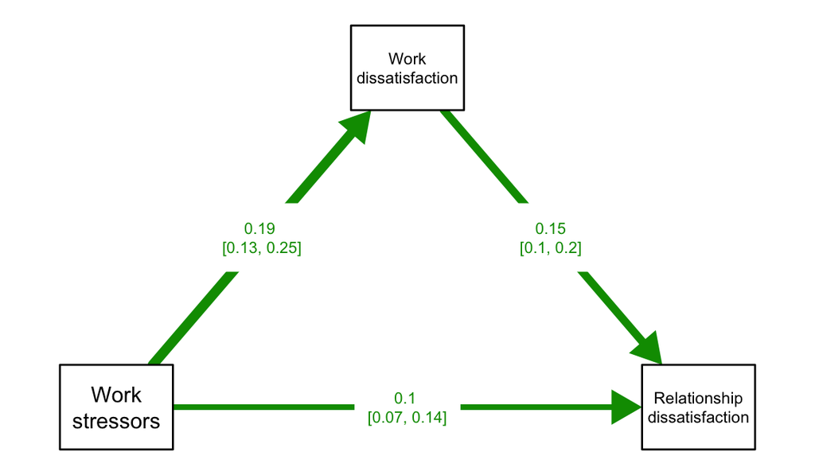

Path diagram of the average level mediation model, with numerical summaries of the relevant parameters.

```r
mlm_path_plot(fit, level = .89,
              xlab = "Work\nstressors",
              mlab = "Work\ndissatisfaction",
              ylab = "Relationship\ndissatisfaction",
              edge.color = NULL)  # Colors edges
```

For a more detailed investigation of the model’s parameters, **bmlm** offers two methods for plotting the samples from each parameter’s posterior distribution. These are obtained by a call to `mlm_pars_plot(type = X)` where `X` can be either `hist` for histograms, or `coefplot` for a coefficient plot. If plotting a coefficient plot, the user may specify `level` to set the “confidence level”, which is represented by the length of the lines surrounding each point estimate.

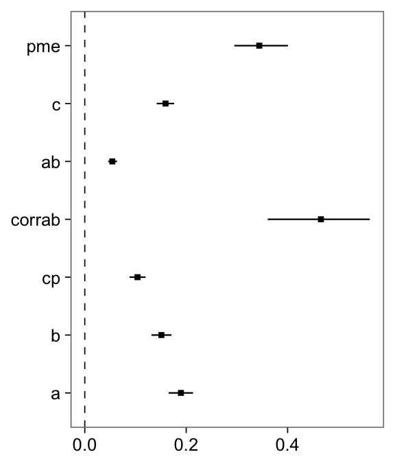

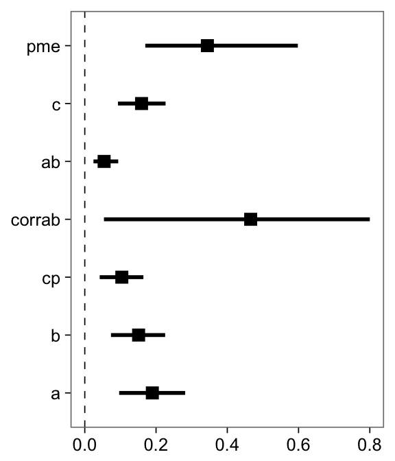

Figure 2. A coefficient plot.

```r
mlm_pars_plot(fit, type = "coefplot", level = .50)
mlm_pars_plot(fit, type = "coefplot", level = .99,
              p_size = 3)  # Changes size of points
```

The user can also specify the parameters to show on the plot, as illustrated in the next histograms:

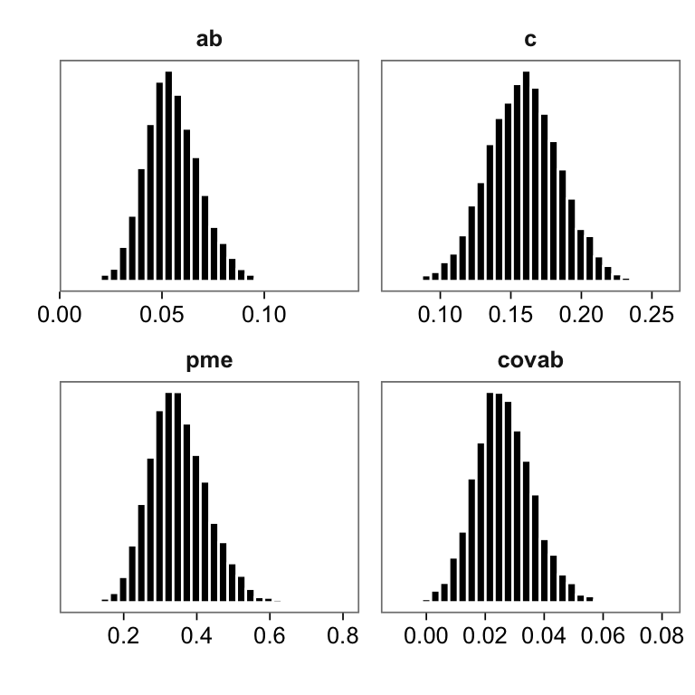

Histograms for a selection of parameters.

```r
mlm_pars_plot(fit, type = "hist", pars = c("ab", "c", "pme", "covab"))
```

The histograms are useful for visually assessing the shape of each marginal posterior distribution.

More complex plots are also possible:

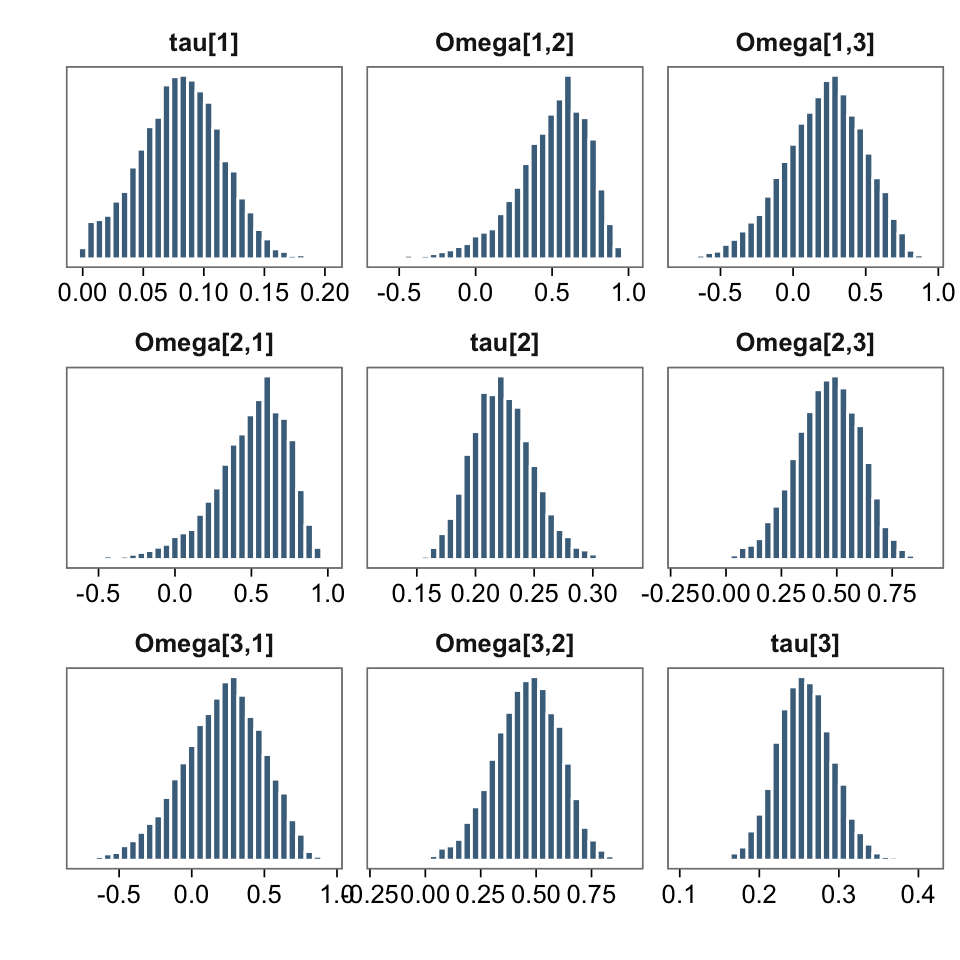

Varying effects standard deviations (tau) and correlations (Omega).

```r
mlm_pars_plot(fit, type = "hist", pars = c(
    "tau[1]", "Omega[1,2]", "Omega[1,3]",
    "Omega[2,1]", "tau[2]", "Omega[2,3]",
    "Omega[3,1]", "Omega[3,2]", "tau[3]"),
    nrow = 3, color = "skyblue4")
```

The first three positions (1: path `c'`, 2: path `b`, 3: path `a`) of the varying effects SDs ($\tau$) and correlations ($\Omega$) are plotted as histograms. Each histogram represents the MCMC samples of plausible parameter values from the corresponding posterior distribution.

## Person-specific effects

It is also possible to investigate person-specific parameters. These exist with the same name as the average-level parameters, but have “u_” appended to them.

```r
head(mlm_summary(fit, pars = "u_c"))
```

```
##   Parameter Mean   SD Median ci_lwr ci_upr    pprob n_eff Rhat
## 1    u_c[1] 0.12 0.08   0.11  -0.01   0.27 0.941500  8000    1
## 2    u_c[2] 0.10 0.09   0.10  -0.05   0.25 0.889000  8000    1
## 3    u_c[3] 0.11 0.08   0.11  -0.02   0.26 0.933250  4118    1
## 4    u_c[4] 0.37 0.13   0.36   0.18   0.61 0.999875  8000    1
## 5    u_c[5] 0.09 0.09   0.09  -0.07   0.24 0.849125  8000    1
## 6    u_c[6] 0.09 0.08   0.09  -0.06   0.22 0.865500  8000    1
```

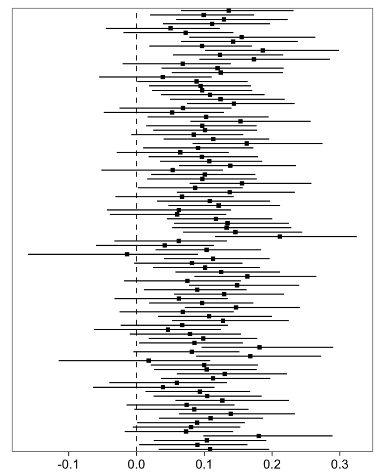

Participant-specific c’ path values with 75% Credible Intervals.

```r
mlm_pars_plot(fit, pars = "u_cp", type = "coef", level = .75) +
    theme(axis.text.y = element_blank(),
          axis.ticks.y = element_blank())
```

# Further information

The functions contained in **bmlm** have various options available for the user. Inspect these options by looking at the functions’ help pages:

```r
?mlm
?mlm_summary
?mlm_path_plot
?mlm_pars_plot
```

Users can also input any valid `stan()` arguments to `mlm()`; see `?stan` for details. The fitted object from `mlm()` is a valid `Stanfit` object, so all `Stanfit` methods are available as well. For example, it is important to assess the performance of Stan’s MCMC algorithms after estimating a model by, for example, inspecting traceplots for convergence problems:

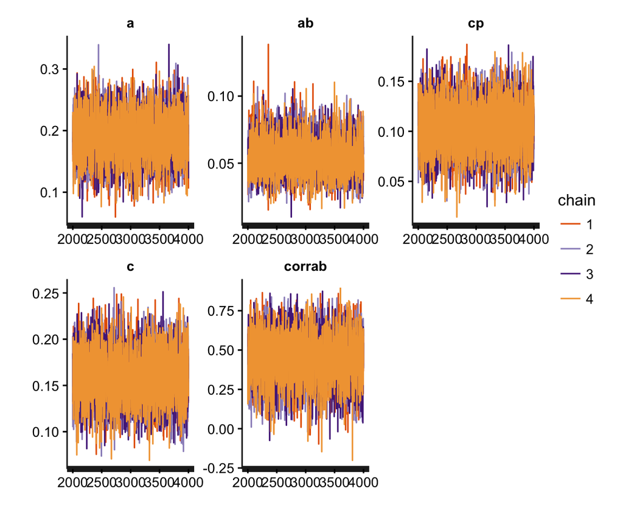

```r
pars <- c("a", "ab", "cp", "c", "corrab")
traceplot(fit, pars = pars)
```

Further modification of the model is possible through modifying the Stan code underlying `mlm()`. To obtain the Stan code for the multilevel mediation model, run `get_stancode()`

```r
cat(get_stancode(fit))  # Wrap inside cat() for nicer printing
```

```
## // Stan code for multilevel mediation model
##
## data {
##     int<lower=1> N;             // Number of observations
##     int<lower=1> J;             // Number of participants
##     int<lower=1,upper=J> id[N]; // Participant IDs
##     vector[N] X;                // Manipulated variable
##     vector[N] M;                // Mediator
##     vector[N] Y;                // Outcome
##     real prior_scale;           // Prior scale for regression params
##     real intrcpt_scale;         // Prior scale for intercepts
## }
## transformed data{
##     real y_mean;                // Mean of Y
##     int K;                      // Number of predictors
##     y_mean = mean(Y);
##     K = 5;
## }
## parameters{
##     // Regression Y on X and M
##     real dy;                    // Intercept
##     real cp;                    // X to Y effect
##     real b;                     // M to Y effect
##     real<lower=0> sigma_y;      // Residual
##     // Regression M on X
##     real dm;                    // Intercept
##     real a;                     // X to M effect
##     real<lower=0> sigma_m;      // Residual
##
##     // Correlation matrix and SDs of participant-level varying effects
##     cholesky_factor_corr[K] L_Omega;
##     vector<lower=0>[K] tau;
##
##     // Standardized varying effects
##     matrix[K, J] z_U;
## }
## transformed parameters {
##     // Participant-level varying effects obtained from vectorized and
##     // standardized z_U matrix
##     matrix[J, K] U;
```

[output cut: 60 more lines]

```
##     Sigma = quad_form_diag(Omega, tau);
##
##     covab = Sigma[3,2];
##     corrab = Omega[3,2];
##     ab = a*b + covab;
##     c = cp + a*b + covab;
##     pme = ab / c;
##
##     for (j in 1:J) {
##         u_ab[j] = (a + U[j, 3]) * (b + U[j, 2]);
##         u_cp[j] = cp + U[j, 1];
##         u_c[j] = u_cp[j] + u_ab[j];
##         u_pme[j] = u_ab[j] / u_c[j];
##     }
## }
```

# References

Bolger, N., & Laurenceau, J.-P. (2013). *Intensive longitudinal methods: An introduction to diary and experience sampling research*. Guilford Press.